# Lumi Vignette - First Run

Connor Smith

# Lumi Vignette

```r
## try http:// if https:// URLs are not supported
# if (!require(lumi)) {
#   source("https://bioconductor.org/biocLite.R")
#   biocLite("lumi")
# }
library(lumi)
```

## Pre-processing

```r
# control treatment data
data("example.lumiMethy")
example.lumiMethy
```

```
MethyLumiM (storageMode: lockedEnvironment)
assayData: 5000 features, 16 samples
  element names: detection, exprs, methylated, unmethylated
protocolData: none
phenoData
  sampleNames: Treat1 Treat2 ... Ctrl4.rep (16 total)
  varLabels: sampleID label
  varMetadata: labelDescription
featureData
  featureNames: cg00002426 cg00012386 ... cg27662379 (5000 total)
  fvarLabels: CHR COLOR_CHANNEL
  fvarMetadata: labelDescription
experimentData: use 'experimentData(object)'
Annotation:
```

```r
# titration data
data("example.methyTitration")
example.methyTitration
```

```
MethyLumiM (storageMode: lockedEnvironment)
assayData: 10000 features, 8 samples
  element names: detection, exprs, methylated, unmethylated
protocolData: none
phenoData
  sampleNames: A1 B1 ... E (8 total)
  varLabels: sampleID label
  varMetadata: labelDescription
featureData
  featureNames: cg09234859 cg22654935 ... cg04283392 (10000 total)
  fvarLabels: TargetID SYMBOL COLOR_CHANNEL CHR
  fvarMetadata: labelDescription
experimentData: use 'experimentData(object)'
Annotation:
```

Take a look at PCs to look for batch effects in Control/Treat data

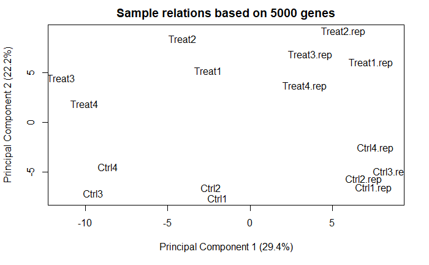

```r
plotSampleRelation(example.lumiMethy,
                   method = 'mds',
                   cv.Th = 0) # covariance threshold
```

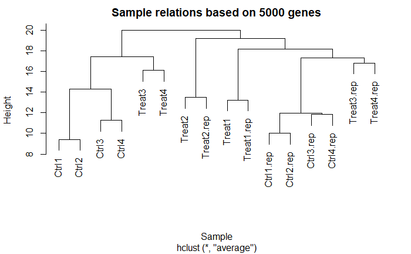

```r
plotSampleRelation(example.lumiMethy,
                   method = 'cluster',
                   cv.Th = 0) # covariance threshold
```

```r
# print sample names
sampleNames(example.lumiMethy)
```

```
 [1] "Treat1"     "Treat2"     "Treat3"     "Treat4"     "Ctrl1"      "Ctrl2"      "Ctrl3"      "Ctrl4"      "Treat1.rep" "Treat2.rep" "Treat3.rep"
[12] "Treat4.rep" "Ctrl1.rep"  "Ctrl2.rep"  "Ctrl3.rep"  "Ctrl4.rep"
```

Look at PC’s for methyl titration data

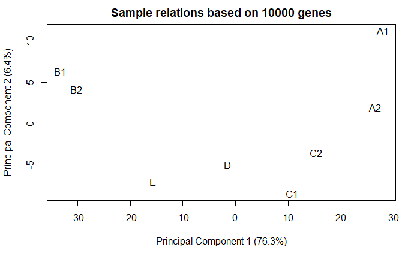

```r
plotSampleRelation(example.methyTitration,
                   method = 'mds',
                   cv.Th = 0) # covariance threshold
```

```r
# print sample names
sampleNames(example.methyTitration)
```

```
[1] "A1" "B1" "C1" "A2" "B2" "C2" "D"  "E"
```

## 3.3 Check the data distribution

- Use density and boxplot to check the distribution
- Density plots of M-values usually have 2 modes, which cannot be properly represented with normal boxplot
  - lumi has a special boxplot function to represent this type of data
  - it seems that *lumi* has modified their boxplot to now be a violin plot?

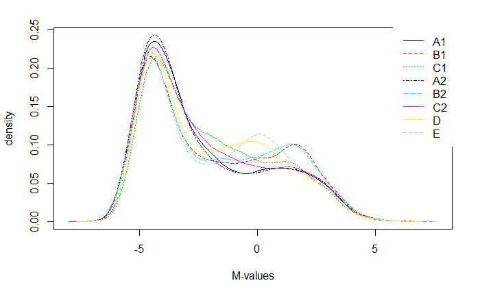

```r
# plot 4
density(example.methyTitration, xlab="M-values")
```

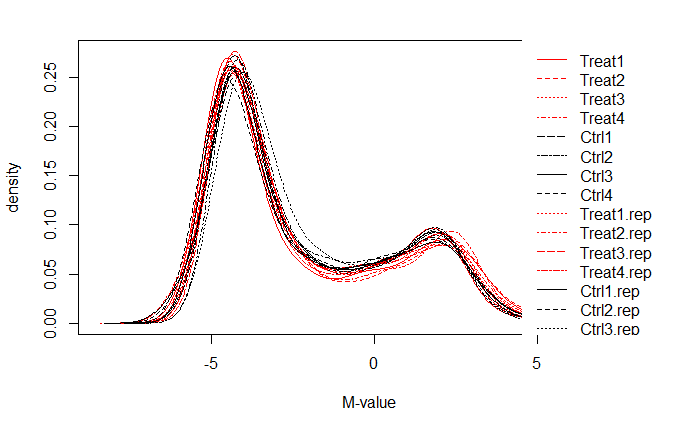

```r
# plot 5
sampleColor <- rep(1, ncol(example.lumiMethy))
sampleColor[grep("Treat", sampleNames(example.lumiMethy))] <- 2
density(example.lumiMethy, col=sampleColor, xlab="M-value")
```

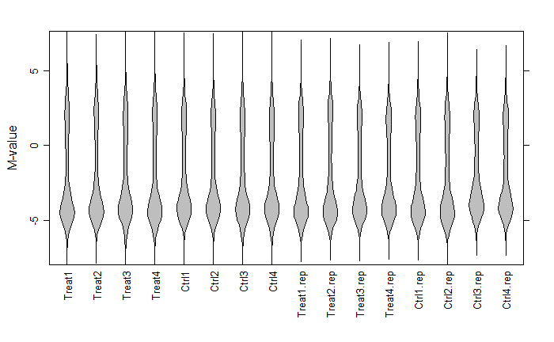

```r
# plot 6
lumi::boxplot(example.lumiMethy)
```

## 3.4 Check color balance

- Two color based system
  - Red channel (extended base is T or A)
    - occurs when the nucleotide after the C in the CpG site has been converted during bisulfite conversion, indicating that it was not methylated
  - Green channel (extended base is C or G)
    - indicates that CpG did not convert after bisulfite conversion due to methylated site
- Reasons for needing normalization of color balance factors:
  - Due to using color based, probe specific variations can be hard to detect
  - Color patterns across experiments are unlikely to be consistent
  - intensities between can be imbalanced
  - effects are non-linear

### QUESTIONS

1. What determines whether an individual site is methylated? Is it just the ratio between the red and green signals at that probe? If so, how can there exist ‘methylated’ probes where the red signal is higher than the green?

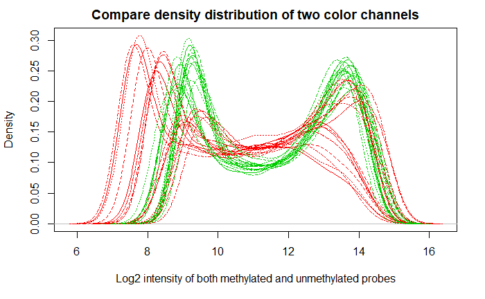

```r
# plot comparison of intensity densities for two color channels
plotColorBias1D(example.lumiMethy)
```

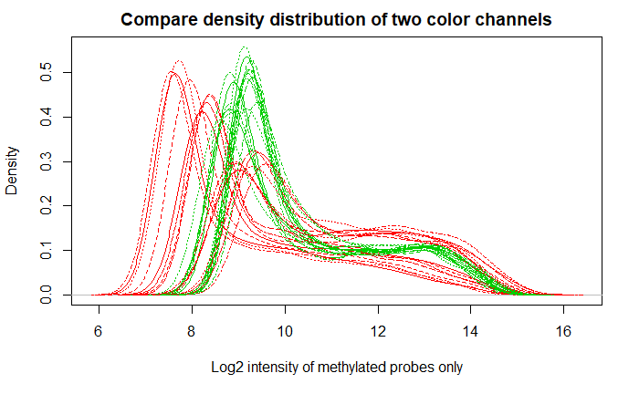

```r
# plot methy sites only
plotColorBias1D(example.lumiMethy, channel = 'methy')
```

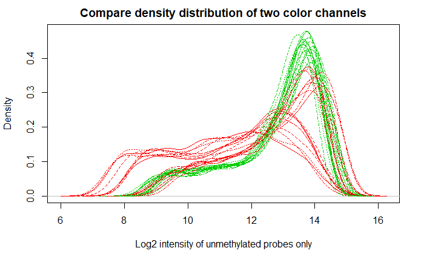

```r
# plot unmethylated only
plotColorBias1D(example.lumiMethy, channel = 'unmethy')
```

```r
# summary of intensities for individual samples
colorBiasSummary(example.lumiMethy[,1:8], channel = 'methy')
```

```
$red
           Treat1    Treat2    Treat3    Treat4     Ctrl1     Ctrl2     Ctrl3     Ctrl4
Min.     7.238405  7.434628  6.832890  6.870365  7.523562  7.442943  6.954196  7.044394
1st Qu.  8.199672  8.357552  7.672425  7.515700  8.375039  8.290019  7.607330  7.912889
Median   8.974415  8.965784  8.082149  7.982994  9.092757  8.971544  8.071462  8.434628
Mean     9.746366  9.779961  8.943616  8.889048  9.753410  9.707109  8.920251  9.276788
3rd Qu. 11.179909 10.993646  9.943980 10.033423 10.894060 10.884171  9.970106 10.398744
Max.    14.807053 14.935533 14.635775 14.429538 14.904635 14.814783 14.709730 14.621651

$green
           Treat1    Treat2    Treat3    Treat4     Ctrl1     Ctrl2     Ctrl3     Ctrl4
Min.     8.233620  8.573647  8.388017  8.103288  8.531381  8.303781  8.459432  8.357552
1st Qu.  8.859534  9.233620  9.079485  8.784635  9.174926  9.236014  9.138271  9.202124
Median   9.471675  9.746514  9.529431  9.339850  9.779719  9.800900  9.631177  9.756556
Mean    10.321203 10.532459 10.321668 10.147636 10.504364 10.540038 10.424651 10.498006
3rd Qu. 11.782384 11.740201 11.484571 11.540370 11.723660 11.755095 11.649031 11.757390
Max.    14.642277 14.809316 14.556446 14.342491 14.736508 14.751230 14.634868 14.558122
```

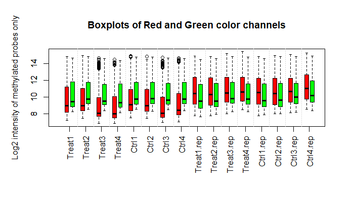

```r
# plot boxplopt of intensities of methylated probes
boxplotColorBias(example.lumiMethy, channel = 'methy')
```

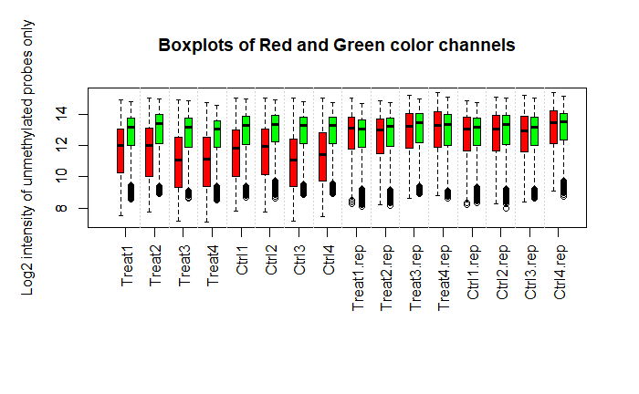

```r
# plot boxplot of intensities of unmethylated probes
boxplotColorBias(example.lumiMethy, channel = 'unmethy')
```

Plotting on two axes can show the color bias present in samples:

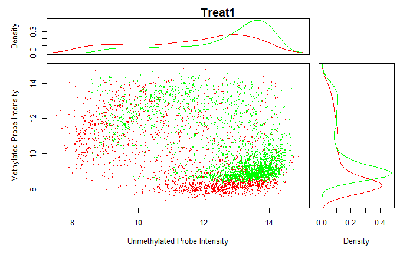

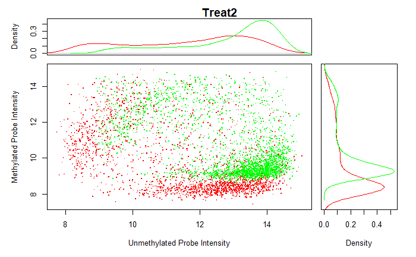

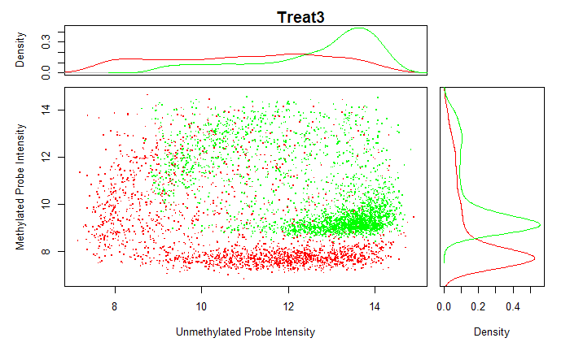

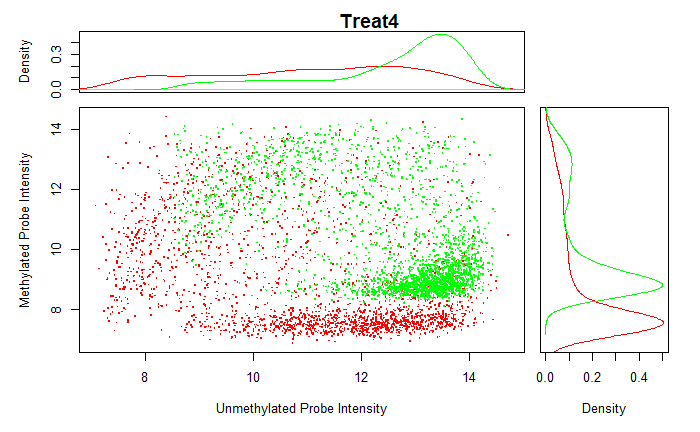

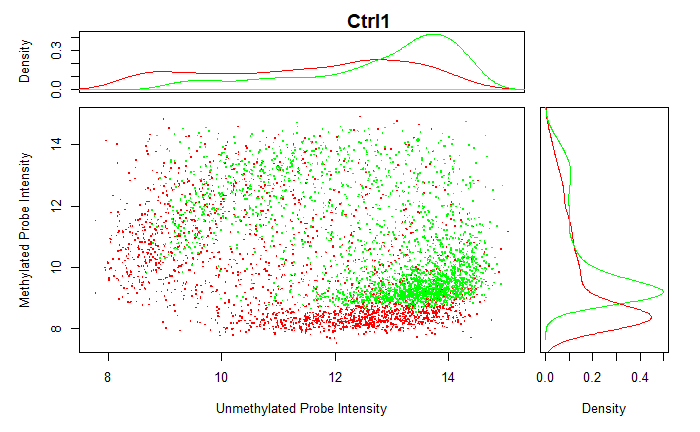

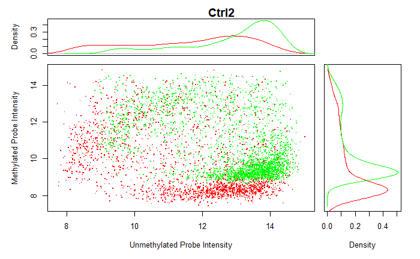

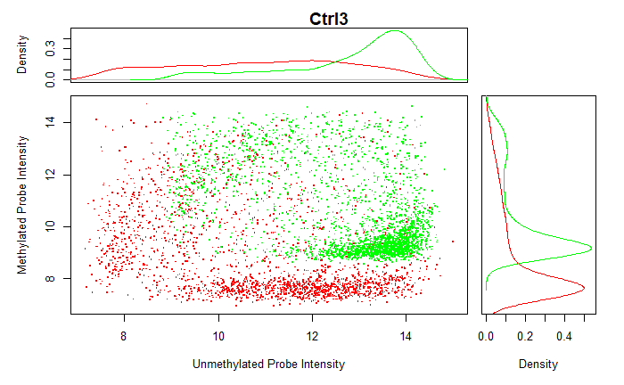

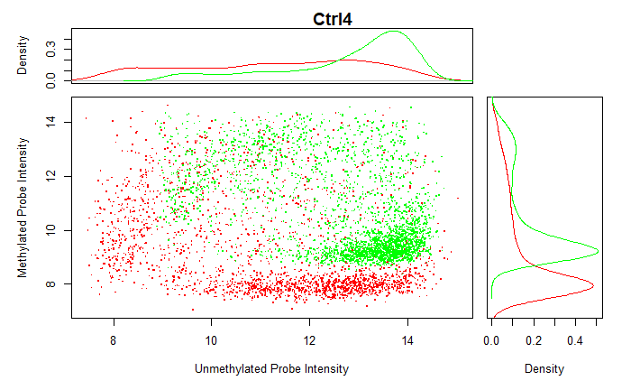

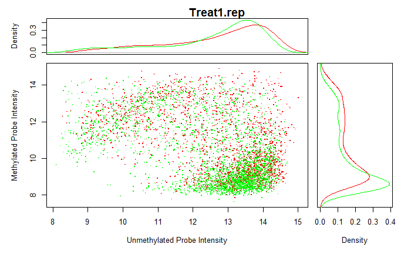

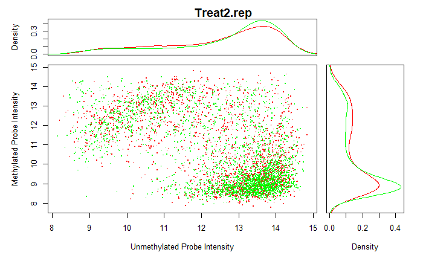

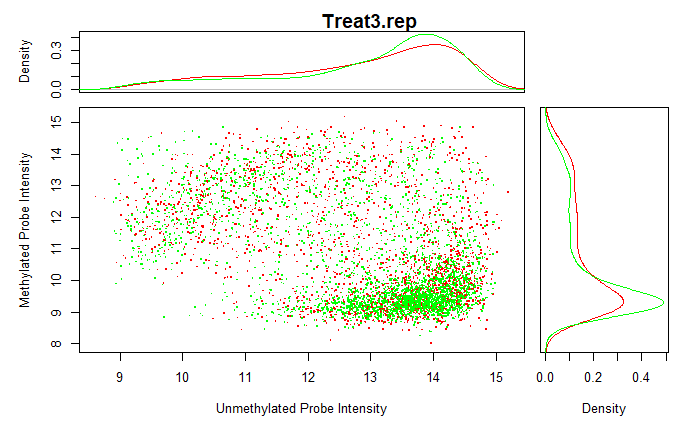

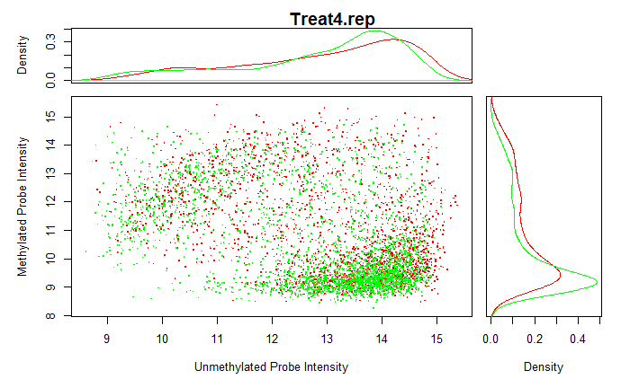

[4 more figures not shown]

```r
sample_count <- length(sampleNames(example.lumiMethy))
for (i in 1:sample_count) {
  plotColorBias2D(example.lumiMethy,
                  selSample = i,
                  cex = 2)
  title(sampleNames(example.lumiMethy)[i])
}
```

## 3.5 Quality assessment based on distribution of CpG-site intensity

- CpG-site should be fixed (M+U=S), total should not fluctuate greatly
  - this means that if M goes up, U should go down
  - look for differences in CpG-site intensities across samples in different conditions (batches)

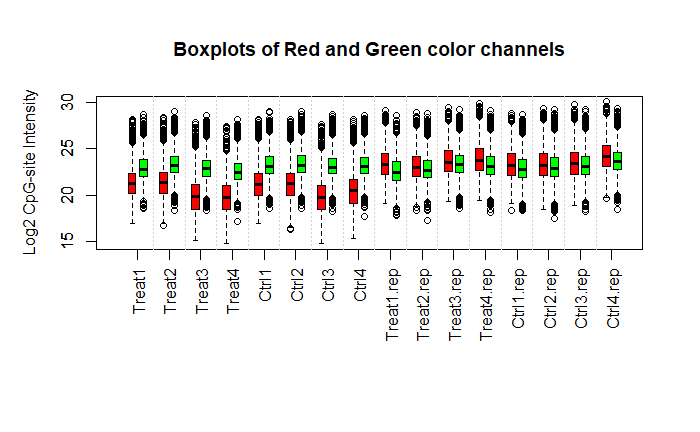

```r
# boxplot of summed intensities
boxplotColorBias(example.lumiMethy, channel='sum') #sums the two channels
```

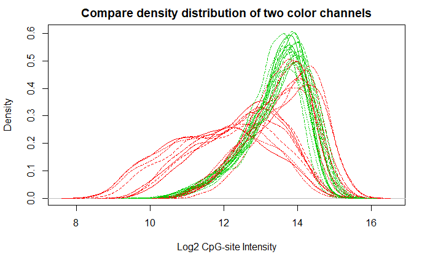

```r
# density plot of summed intensities
plotColorBias1D(example.lumiMethy, channel='sum')
```

From these, we can see that the red signal seems to be changing the most between the two sample runs (repeated techniques).  
We will also plot the estimated intensities.  
I believe this is another one that has been modified since the vignette was created?

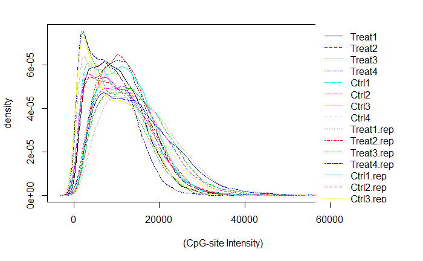

```r
# plot desnity plot
density(estimateIntensity(example.lumiMethy),
        xlab="(CpG-site Intensity)")
```

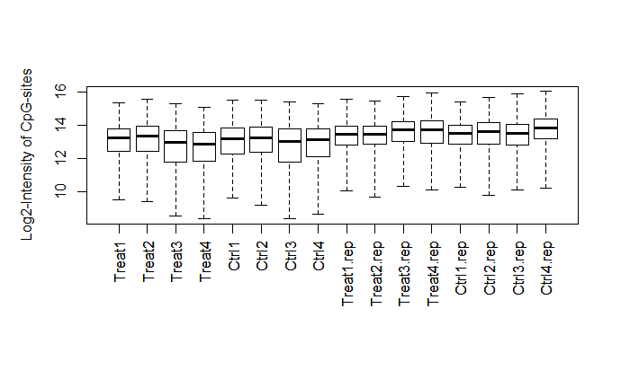

```r
# plot site intensity boxplot
boxplot(estimateIntensity(example.lumiMethy))
```

We can see some difference between the two batches which should have be directly replicated. We can use a pairwise pliot to see this even more:

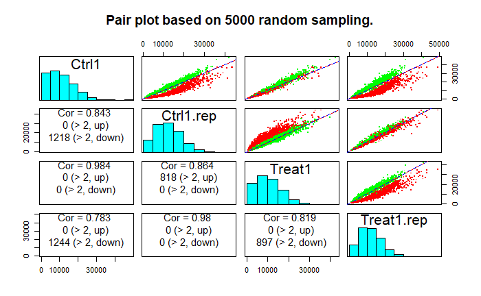

```r
# get color channel
colorChannel <- as.character(pData(featureData(example.lumiMethy))[, "COLOR_CHANNEL"])
# replace with consistent naming convention for r colors
colorChannel[colorChannel == 'Red'] <- 'red'
colorChannel[colorChannel == 'Grn'] <- 'green'
# subset the sample for pairwise comparison
selSample <- c("Ctrl1","Ctrl1.rep","Treat1","Treat1.rep")
# plot pairwise comparison
pairs(estimateIntensity(example.lumiMethy[,selSample]),
      dotColor=colorChannel)
```

it seems that estimateIntensity is not returning the log2(intensity) values we would expect. I am assuming this is a change to the code, as I am unable to replicate the graphs in the vignette using the same commands.

## 3.6 Color Balance Adjustment

- We can choose to correct the color balance issues now or later
  - vignette recommends now as we may not have the color channel info for analysis later
- *lumi* provides a function **lumiMethyC** which is used for color balance adjustment
  - two options: “quantile” and “ssn”
    - non-equal number of probes means regular quantile will not work
    - **lumiMethyC** has a method **smootQuantileNormalization**
      - corrects for issue with quantile normalization in sparse density regions

Do the correction using lumiMethyC:

```r
lumiMethy.c.adj <- lumiMethyC(example.lumiMethy)
```

```
Perform quantile color balance adjustment ...
Processing sample Treat1 ...
Processing sample Treat2 ...
Processing sample Treat3 ...
Processing sample Treat4 ...
Processing sample Ctrl1 ...
Processing sample Ctrl2 ...
Processing sample Ctrl3 ...
Processing sample Ctrl4 ...
Processing sample Treat1.rep ...
Processing sample Treat2.rep ...
Processing sample Treat3.rep ...
Processing sample Treat4.rep ...
Processing sample Ctrl1.rep ...
Processing sample Ctrl2.rep ...
Processing sample Ctrl3.rep ...
Processing sample Ctrl4.rep ...
```

Plot the color balanced plots:

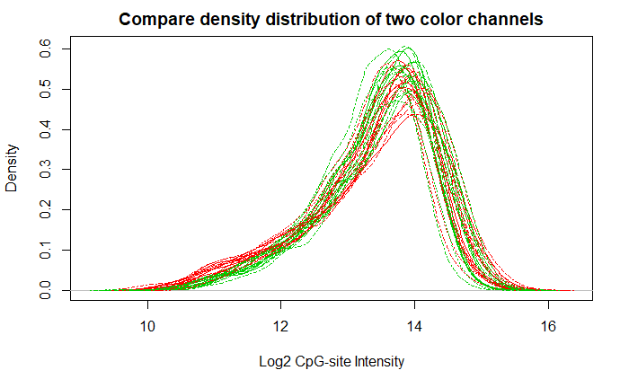

```r
# plot density intensity estimate after correction
plotColorBias1D(lumiMethy.c.adj, channel = 'sum')
```

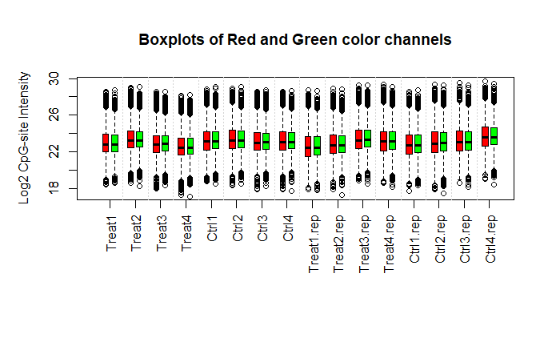

```r
# plot intensity estimnate boxplot after correction
boxplotColorBias(lumiMethy.c.adj, channel = 'sum')
```

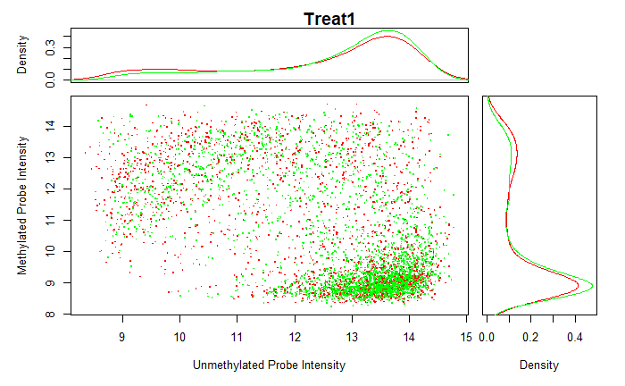

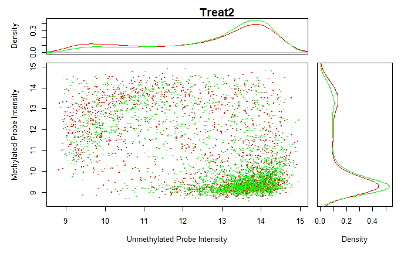

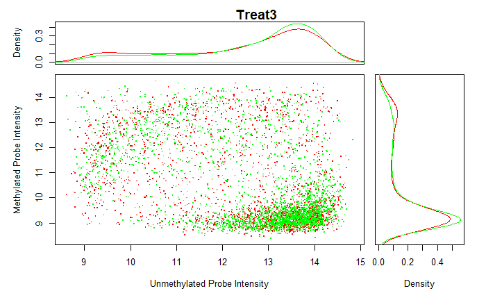

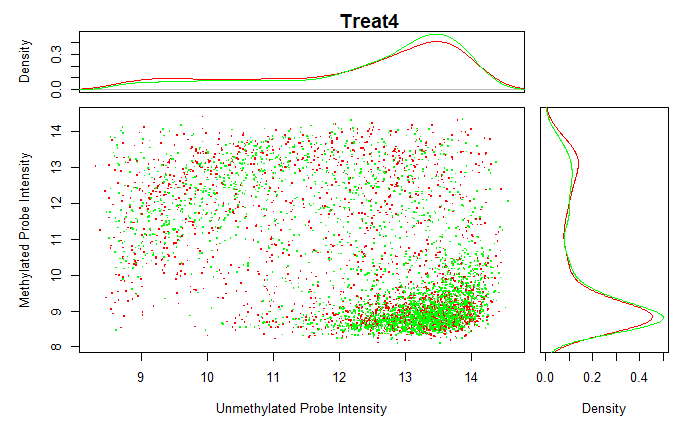

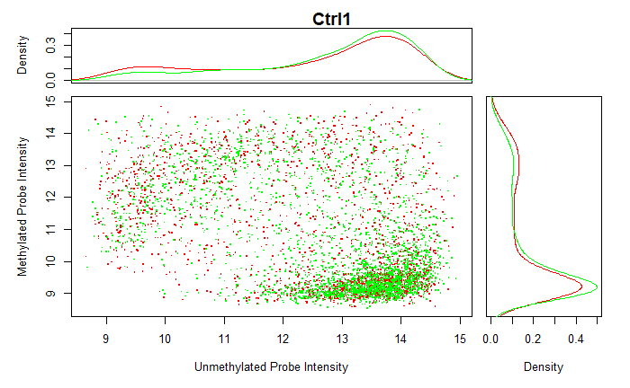

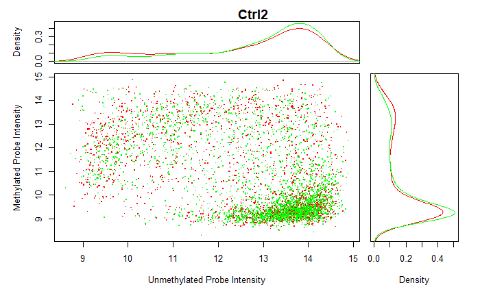

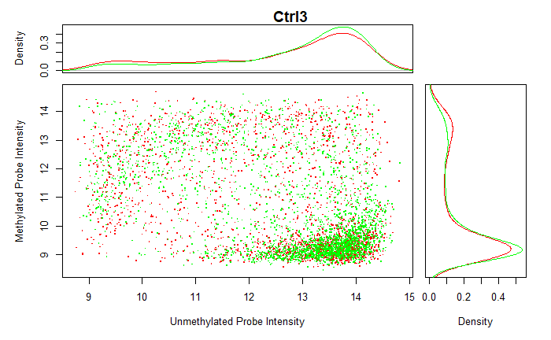

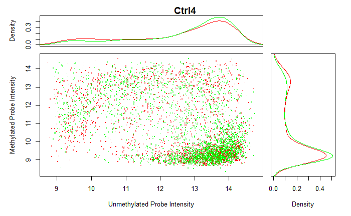

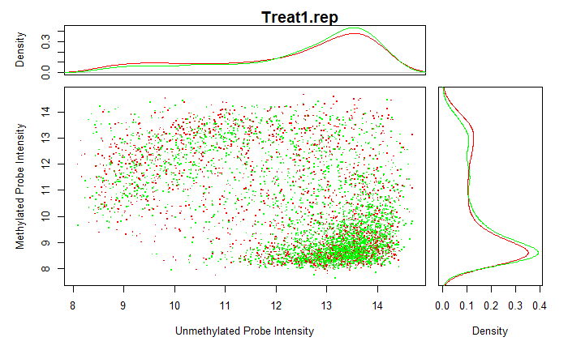

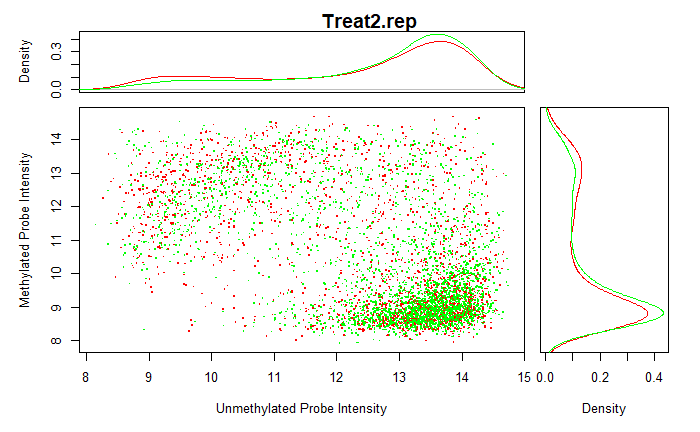

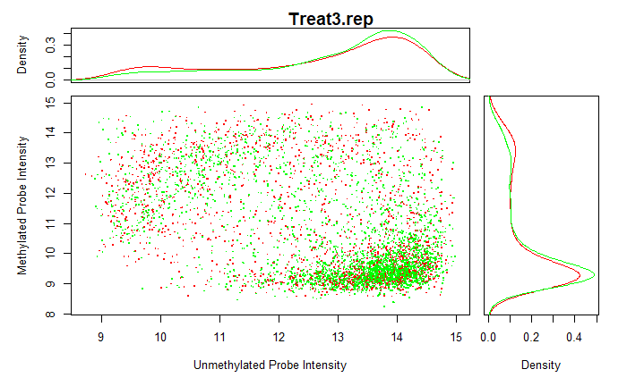

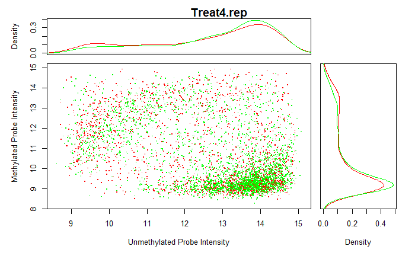

[4 more figures not shown]

```r
# plot 2d channel comparisons for all samples
sample_count <- length(sampleNames(lumiMethy.c.adj))
for (i in 1:sample_count) {
  plotColorBias2D(lumiMethy.c.adj,
                  selSample = i,
                  cex = 2)
  title(sampleNames(lumiMethy.c.adj)[i])
}
```

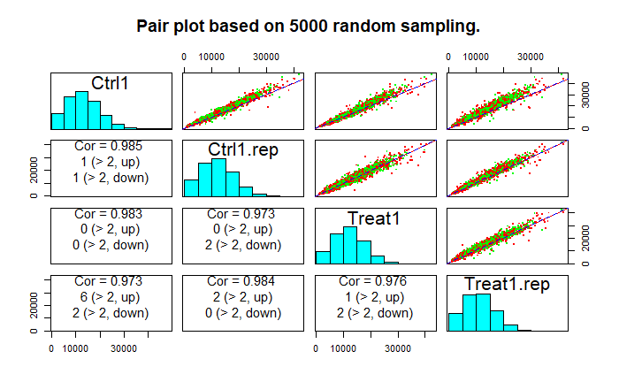

```r
# plot pairwise after color adjust,ment
pairs(estimateIntensity(lumiMethy.c.adj[,selSample]),
      dotColor=colorChannel)
```

We see a stark change in the disparity between the groups now, with the colors much more inline with what we’d expect

## 3.7 Background level correction

- Illumina includes negative control probes, stored as controlData
  - background is estimated as median of these probes
  - EXECPT this data is often not exported with the actual data, so we find other ways to estimate background noise to eliminate
  - two color channels
    - because of the two color channels, background correction should either be done *after* color balancing OR done individually on each color channel, as they will each have their own values
- Estimation operates under assumption that many CpG sites are unmethylated, creating a density mode of intensities measured by the methylated probes

Plot uncorrected background for first five samples:

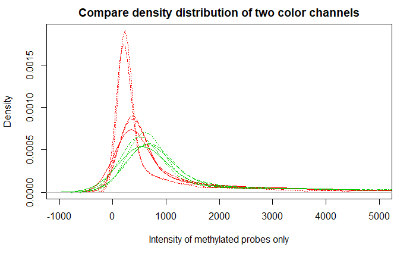

```r
# plot background mode of methylated probe data of first five example samples
plotColorBias1D(example.lumiMethy[,1:5], channel = 'methy', xlim=c(-1000,5000), logMode = FALSE)
```

We see a shift between the two colors. We will now correct this using the **lumiMethyB** function, which uses **estimateMethylationBG** for each sample and passes the result to **bgAdjustMethylation** to adjust for the background levels. We will run this two ways, once on the non color-corrected data and once on the color corrected.

```r
# adjust bg for seperate channels
lumiMethy.b.adj <- lumiMethyB(example.lumiMethy,
                              method = 'bgAdjust2C',
                              separateColor = TRUE)
```

```
Perform bgAdjust2C background correction ...
```

```r
# adjust samples that have been color corrected
lumiMethy.bc.adj <- lumiMethyB(lumiMethy.c.adj, method = 'bgAdjust2C')
```

```
Perform bgAdjust2C background correction ...
```

We will not plot the results of these and compare

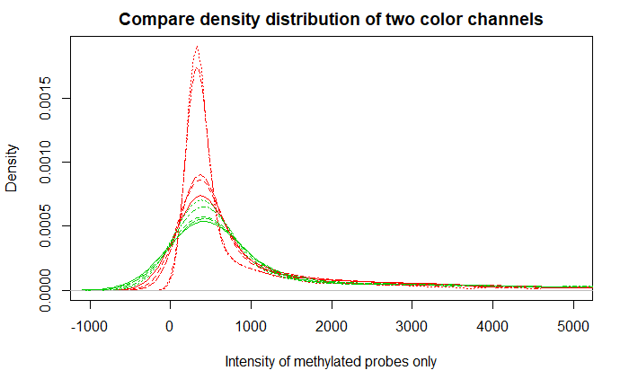

```r
# plot bg mode after bg adjustment w/o color adjustment
plotColorBias1D(lumiMethy.b.adj[,1:5], channel = 'methy', xlim = c(-1000,5000), logMode = FALSE)
```

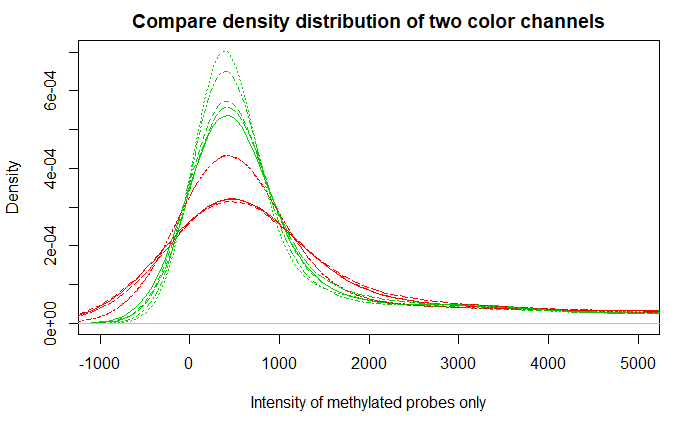

```r
# plot bg mode after bg adjustment w/ color adjustment
plotColorBias1D(lumiMethy.bc.adj[,1:5], channel = 'methy', xlim = c(-1000,5000), logMode = FALSE)
```

## 3.8 Data normalization

- We cannot use same assumptions in this analysis as other mRNA expression microarrays
  - due to highly variable methylation
  - Instead, we normalize at the probe level (normalize methylated and unmethylated probes instead of summarized levels)
- **lumiMethyN** normalizes at probe level
  - uses “quantile” and “ssn”
  - user can supply own normalization methods so long as data format is consistent with package expectations (import matrix output matrix)
  - uses methods from background detection to estimate background and then rescale

```r
# perform SSN normalization
lumiMethy.c.ssn <- lumiMethyN(lumiMethy.c.adj, method = 'ssn')
```

```
Perform ssn normalization ...
```

```r
# perform quantile normalization
lumiMethy.c.quantile <- lumiMethyN(lumiMethy.c.adj, method = 'quantile')
```

```
Perform quantile normalization ...
```

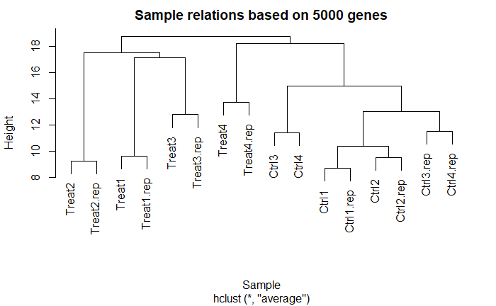

```r
# plot relationships after normalization
plotSampleRelation(lumiMethy.c.ssn, method = 'cluster', cv.Th = 0)
```

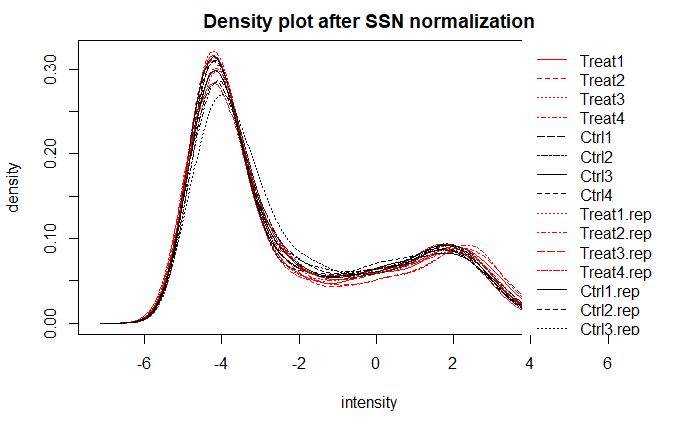

```r
# plot density after ssn
density(lumiMethy.c.ssn, col = sampleColor, main = "Density plot after SSN normalization")
```

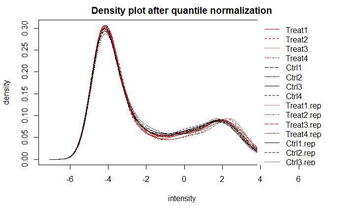

```r
# plot density after quantile
density(lumiMethy.c.quantile, col = sampleColor, main = "Density plot after quantile normalization")
```

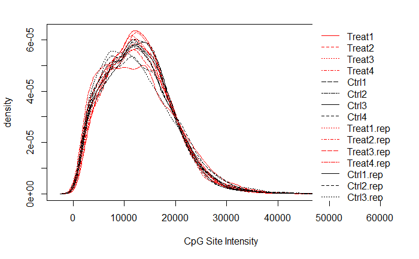

```r
# plot density of CpG-site intensity after ssn
density(estimateIntensity(lumiMethy.c.ssn), col = sampleColor, xlab="CpG Site Intensity")
```

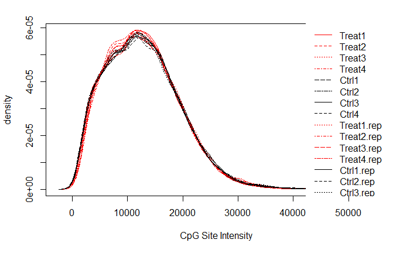

```r
# plot density of CpG-site intensity after quantile
density(estimateIntensity(lumiMethy.c.quantile), col = sampleColor, xlab="CpG Site Intensity")
```

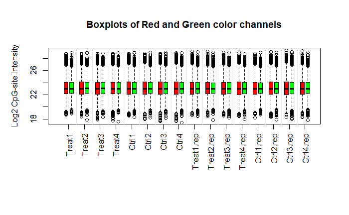

```r
# boxplot of color biasafter quantile normalization
boxplotColorBias(lumiMethy.c.quantile, channel = 'sum')
```

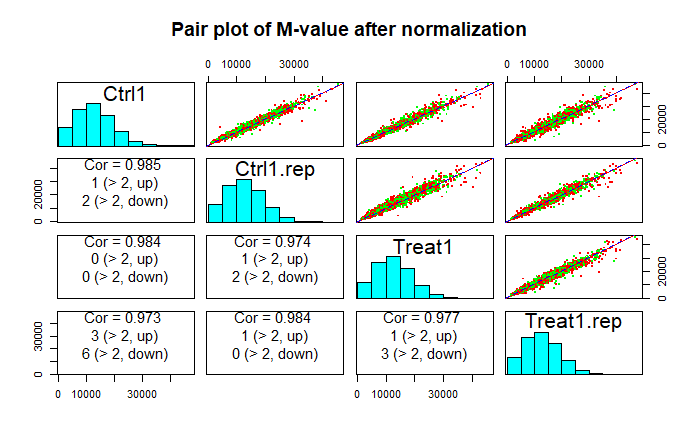

```r
# plot pairwise after color adjust,ment - this plot is not done correctly, need to review
pairs(estimateIntensity(lumiMethy.c.quantile[,selSample]),
      dotColor=colorChannel,
      main = "Pair plot of M-value after normalization")
```

## 3.9 Modeling the methylation status

- M-value alone cannot determine methylation status
  - developed an algorithm to estimate the methy status by fitting a two component Gamma mixture model

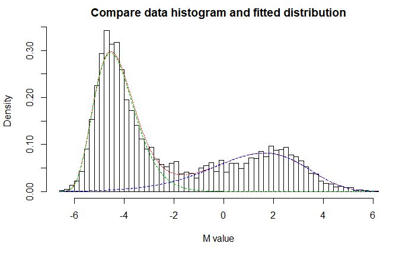

```r
# fit 2 component gamma mix model of first sample
fittedGammaRaw <- gammaFitEM(exprs(example.lumiMethy)[,1], plotMode = TRUE)
```

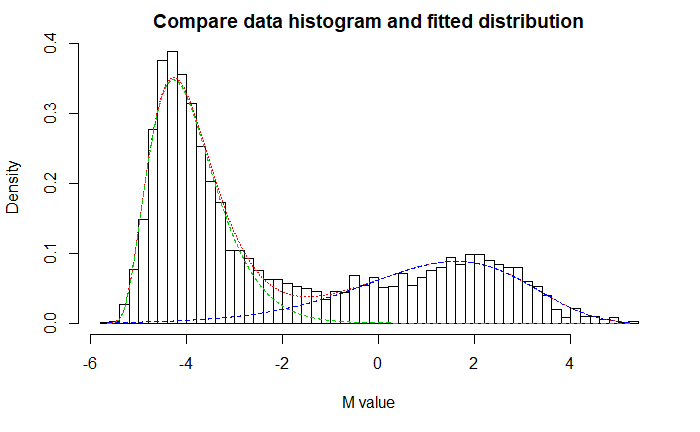

```r
# added in nromalized data to compare effect of cleaning
fittedGammaNorm <- gammaFitEM(exprs(lumiMethy.c.quantile)[,1], plotMode = TRUE)
```

Question: why are we fitting to the raw data and not the cleaned data?

Now we get the methylation statuses:

```r
# estimate methy status based on results of gammaFit
methyCall.raw <-methylationCall(fittedGammaRaw)
table(methyCall.raw)
```

```
methyCall.raw
 Margin   Methy Unmethy
    806    1648    2546
```

```r
# do it with cleaned data as well
methyCall.norm <-methylationCall(fittedGammaNorm)
table(methyCall.norm)
```

```
methyCall.norm
 Margin   Methy Unmethy
    788    1618    2594
```

Also can return exact status/probability for each sample/probe

```r
# estimate status on LumiMethyM object on raw
methyCall.raw.status <- lumiMethyStatus(example.lumiMethy[,1:4])
head(methyCall.raw.status)
```

```
           Treat1    Treat2    Treat3    Treat4
cg00002426 "Margin"  "Margin"  "Methy"   "Methy"
cg00012386 "Unmethy" "Unmethy" "Unmethy" "Unmethy"
cg00013618 "Methy"   "Methy"   "Methy"   "Methy"
cg00014837 "Methy"   "Methy"   "Methy"   "Methy"
cg00020533 "Methy"   "Methy"   "Methy"   "Methy"
cg00021527 "Unmethy" "Unmethy" "Unmethy" "Unmethy"
```

```r
# estimate status on LumiMethyM object on normalized
methyCall.norm.status <- lumiMethyStatus(lumiMethy.c.quantile[,1:4])
head(methyCall.norm.status)
```

```
           Treat1    Treat2    Treat3    Treat4
cg00002426 "Margin"  "Margin"  "Methy"   "Methy"
cg00012386 "Unmethy" "Unmethy" "Unmethy" "Unmethy"
cg00013618 "Methy"   "Methy"   "Methy"   "Methy"
cg00014837 "Methy"   "Methy"   "Methy"   "Methy"
cg00020533 "Methy"   "Methy"   "Methy"   "Methy"
cg00021527 "Unmethy" "Unmethy" "Unmethy" "Unmethy"
```

```r
# retrieve probability matrix on raw
methyCall.raw.prob <- attr(methyCall.raw.status, "probability")
head(methyCall.raw.prob)
```

```
                Treat1      Treat2      Treat3      Treat4
cg00002426 0.553664242 0.910504727 0.987547505 0.992709883
cg00012386 0.005614807 0.005282840 0.004704584 0.004626083
cg00013618 0.999981923 0.999963027 0.999983661 0.999988659
cg00014837 0.999965767 0.999363128 0.999738154 0.999680594
cg00020533 0.999999231 0.999990911 0.999657901 0.999927974
cg00021527 0.008324763 0.005820892 0.004674907 0.004761973
```

```r
# retrieve probability matrix on normalized
methyCall.norm.prob <- attr(methyCall.norm.status, "probability")
head(methyCall.norm.prob)
```

```
                Treat1      Treat2      Treat3      Treat4
cg00002426 0.352641933 0.863644612 0.996216469 0.992086877
cg00012386 0.006139933 0.006737907 0.005934686 0.005952974
cg00013618 0.999938157 0.999896183 0.999994597 0.999966903
cg00014837 0.999909809 0.999443790 0.999984219 0.999697391
cg00020533 0.999996609 0.999991116 0.999980635 0.999943688
cg00021527 0.008407967 0.006461078 0.005855940 0.005108277
```

I would like to explore this further to see which ones the color correction/normalization affected